# Citation Graphs

## Department Citations Overview

The following are a series of graphs that provide an overview about citation rates from research performed by the Department. They are derived from Google Scholar, and as a result, do not include members of the department who do not have Google Scholar profiles. Ids were found by manually searching Google Scholar against current faculty listed on the Department’s Website. The following faculty members do not have profiles on Google Scholar: Desmond Jagmohan, Daniel Lee, Kinch Hoekstra, Terri Bimes, Steven Vogel, Jonah Levy, Martha Wilfahrt, and Pradeep K. Chhibber.

Publications drawn from Google Scholar are further processed to remove duplicates, working papers, conference papers, and other work that has not been formally published. Google Scholar “uses automated software, known as ‘robots’ or”crawlers”, to fetch your files for inclusion in the search results. It operates similarly to regular Google search” (Google Scholar n.d).

## Faculty Publications in Top Journals

Berkeley faculty have been consistently successful in placing work in top academic journals. This set of graphs shows the department record over time. The top journals included are: “American Political Science Review”, “American Journal Of Political Science”,“Journal Of Politics”, “International Organization”, “Comparative Political Studies”, “Political Analysis”, “PNAS”, “Science”, “British Journal Of Political Science”,“The Journal Of Politics”, “The British Journal of Political Science”, “World Politics”, “Quarterly Journal of Economics”, and the “American Economic Review”

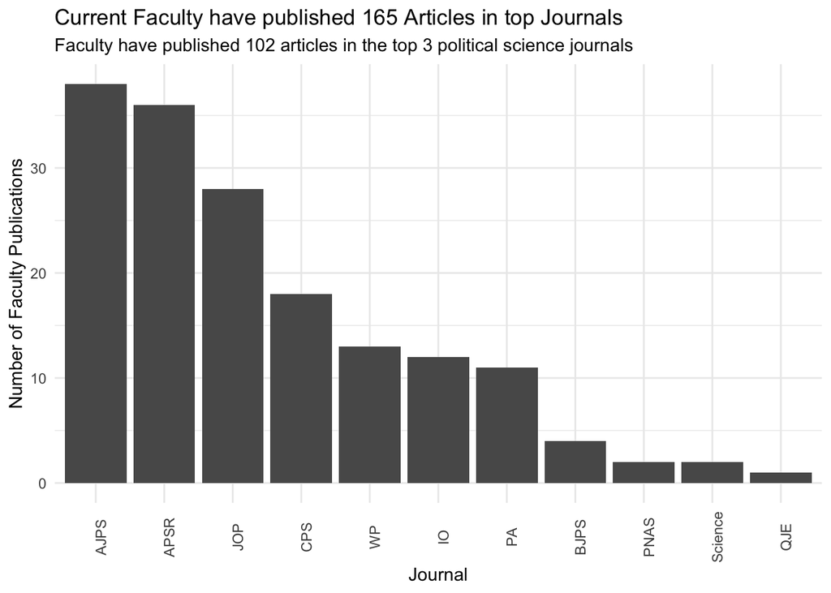

We can also break down these publication by faculty member. The department has a wide number of faculty publishing in top journals.

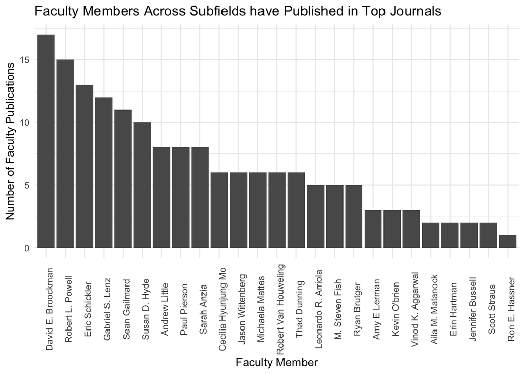

## Recent Research

Citations accumulate over time. To limit this possibility, we can look at all publications and citations from 2010 onwards. The department’s work over the last decade is well cited.

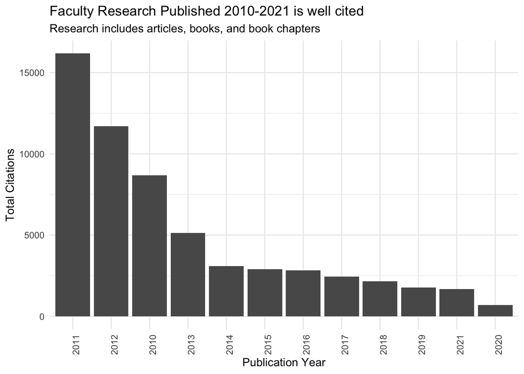

Note that the previous graph is ordered by top citations instead of years. We can plot the same information keeping the years in order.

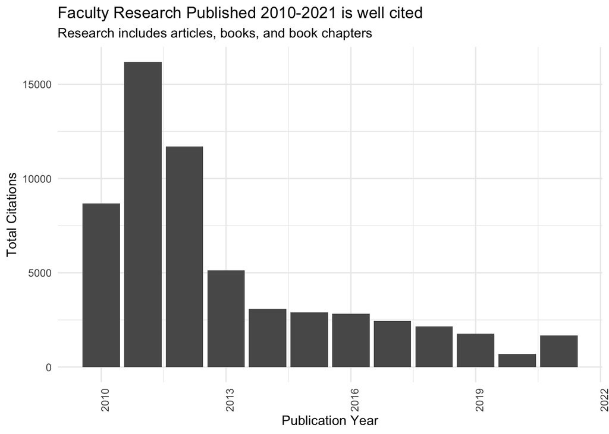

We can also break this information down by faculty member.

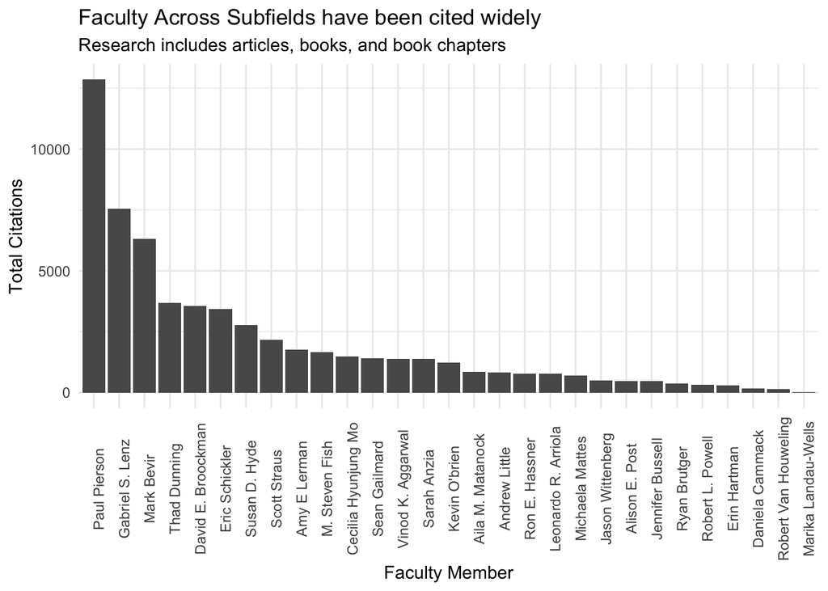

## Field Defining Work.

Measuring the contributions of research can be challenging. To create a baseline, we looked at all work that received at least 200 citations.

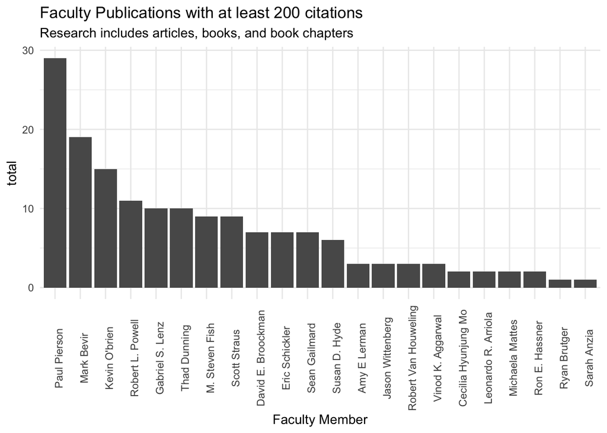

Similarly we can look at the rate at which faculty publish work that is heavily cited. A simplified “hit rate” considers the percentage of publications that have at least 200 citations among faculty members with at least ten publications.

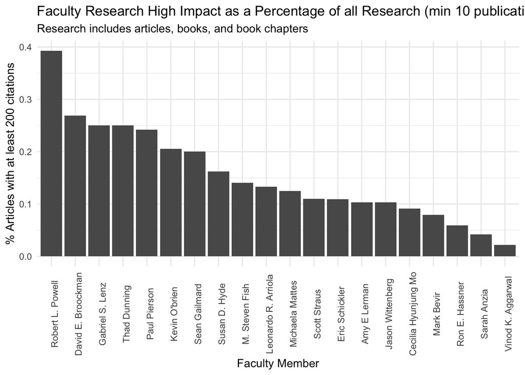

## Works

### Publications with at least 750 citations

| Name | title | journal | cites | year |
| --- | --- | --- | --- | --- |
| Paul Pierson | Increasing returns, path dependence, and the study of politics | American Political Science Review | 9890 | 2000 |
| Paul Pierson | Politics in time | Princeton University Press | 8281 | 2011 |
| Paul Pierson | Dismantling the welfare state?: Reagan, Thatcher and the politics of retrenchment | Cambridge University Press | 6301 | 1994 |
| Paul Pierson | The new politics of the welfare state | World Politics | 6030 | 1996 |
| Gabriel S. Lenz | Evaluating online labor markets for experimental research: Amazon. com’s Mechanical Turk | Political Analysis | 4475 | 2012 |
| Jason Wittenberg | Making the most of statistical analyses: Improving interpretation and presentation | American Journal Of Political Science | 4446 | 2000 |
| Paul Pierson | The path to European integration: a historical institutionalist analysis | Comparative Political Studies | 2959 | 1996 |
| Paul Pierson | When effect becomes cause: Policy feedback and political change | World Politics | 2891 | 1993 |
| Eric Schickler | Partisan hearts and minds | Yale University Press | 2886 | 2008 |
| Paul Pierson | Winner-take-all politics: How Washington made the rich richer–and turned its back on the middle class | Simon And Schuster | 2369 | 2010 |
| Jason Wittenberg | CLARIFY: Software for interpreting and presenting statistical results | Journal Of Statistical Software | 2275 | 2003 |
| Kevin O’brien | Rightful resistance in rural China | Cambridge University Press | 1975 | 2006 |
| Paul Pierson | Historical institutionalism in contemporary political science | W.W. Norton | 1916 | 2002 |
| Paul Pierson | Coping with permanent austerity: welfare state restructuring in affluent democracies | Revue Française De Sociologie | 1620 | 2002 |
| Thad Dunning | Brokers, voters, and clientelism: The puzzle of distributive politics | Cambridge University Press | 1472 | 2013 |
| Mark Bevir | Interpreting British Governance | Routledge | 1371 | 2003 |
| Scott Straus | The Order of Genocide: Race, Power, and War in Rwanda | The Journal Of Modern African Studies | 1298 | 2006 |
| Robert L. Powell | In the Shadow of Power: States and Strategies in International Politics | Princeton University Press | 1197 | 1999 |
| Eric Schickler | Congress and its members | CQ Press | 1189 | 2021 |
| Robert L. Powell | War as a Commitment Problem | International Organization | 1170 | 2006 |
| Paul Pierson | The limits of design: Explaining institutional origins and change | Governance | 1156 | 2000 |
| Eric Schickler | Disjointed pluralism | Princeton University Press | 1071 | 2011 |
| M. Steven Fish | Islam and authoritarianism | World Politics | 1024 | 2002 |
| Paul Pierson | European social policy: between fragmentation and integration | Brookings Institution Press | 954 | 1995 |
| Thad Dunning | Crude democracy: Natural resource wealth and political regimes | Cambridge University Press | 954 | 2008 |
| Thad Dunning | Natural experiments in the social sciences: a design-based approach | Cambridge University Press | 934 | 2012 |
| Mark Bevir | The logic of the history of ideas | Cambridge University Press | 923 | 1999 |
| Paul Pierson | Not just what, but when: Timing and sequence in political processes | Studies In American Political Development | 909 | 2000 |
| Paul Pierson | Irresistible forces, immovable objects: post-industrial welfare states confront permanent austerity | Journal Of European Public Policy | 890 | 1998 |
| Paul Pierson | The Comparative Political Economy | The New Politics Of The Welfare State | 870 | 2001 |
| Kevin O’brien | Selective policy implementation in rural China | Comparative Politics | 869 | 1999 |
| Mark Bevir | Governance: A very short introduction | Oxford University Press | 848 | 2012 |
| Mark Bevir | Democratic governance | Princeton University Press | 834 | 2010 |
| Gabriel S. Lenz | Follow the Leader? How Voters Respond to Politicians’ Performance and Policies | University Of Chicago Press | 832 | 2012 |
| Mark Bevir | Key concepts in governance | Sage | 801 | 2009 |
| M. Steven Fish | Conceptualizing and measuring democracy: A new approach | Perspectives On Politics | 785 | 2011 |
| Kevin O’brien | Rightful resistance | World Politics | 773 | 1996 |

### Publications with at least 1000 Citations

| Name | title | journal | cites | year |
| --- | --- | --- | --- | --- |
| Paul Pierson | Increasing returns, path dependence, and the study of politics | American Political Science Review | 9890 | 2000 |
| Paul Pierson | Politics in time | Princeton University Press | 8281 | 2011 |
| Paul Pierson | Dismantling the welfare state?: Reagan, Thatcher and the politics of retrenchment | Cambridge University Press | 6301 | 1994 |
| Paul Pierson | The new politics of the welfare state | World Politics | 6030 | 1996 |
| Gabriel S. Lenz | Evaluating online labor markets for experimental research: Amazon. com’s Mechanical Turk | Political Analysis | 4475 | 2012 |
| Jason Wittenberg | Making the most of statistical analyses: Improving interpretation and presentation | American Journal Of Political Science | 4446 | 2000 |
| Paul Pierson | The path to European integration: a historical institutionalist analysis | Comparative Political Studies | 2959 | 1996 |
| Paul Pierson | When effect becomes cause: Policy feedback and political change | World Politics | 2891 | 1993 |
| Eric Schickler | Partisan hearts and minds | Yale University Press | 2886 | 2008 |
| Paul Pierson | Winner-take-all politics: How Washington made the rich richer–and turned its back on the middle class | Simon And Schuster | 2369 | 2010 |
| Jason Wittenberg | CLARIFY: Software for interpreting and presenting statistical results | Journal Of Statistical Software | 2275 | 2003 |
| Kevin O’brien | Rightful resistance in rural China | Cambridge University Press | 1975 | 2006 |
| Paul Pierson | Historical institutionalism in contemporary political science | W.W. Norton | 1916 | 2002 |
| Paul Pierson | Coping with permanent austerity: welfare state restructuring in affluent democracies | Revue Française De Sociologie | 1620 | 2002 |
| Thad Dunning | Brokers, voters, and clientelism: The puzzle of distributive politics | Cambridge University Press | 1472 | 2013 |
| Mark Bevir | Interpreting British Governance | Routledge | 1371 | 2003 |
| Scott Straus | The Order of Genocide: Race, Power, and War in Rwanda | The Journal Of Modern African Studies | 1298 | 2006 |
| Robert L. Powell | In the Shadow of Power: States and Strategies in International Politics | Princeton University Press | 1197 | 1999 |
| Eric Schickler | Congress and its members | CQ Press | 1189 | 2021 |
| Robert L. Powell | War as a Commitment Problem | International Organization | 1170 | 2006 |
| Paul Pierson | The limits of design: Explaining institutional origins and change | Governance | 1156 | 2000 |
| Eric Schickler | Disjointed pluralism | Princeton University Press | 1071 | 2011 |
| M. Steven Fish | Islam and authoritarianism | World Politics | 1024 | 2002 |